# rentrez Searching and Plotting

10/5/2017

## Creating a plot using only `entrez_search()`

- Using entrez_search() includes the number of records matching a given search.
- This means you can learn a little about the composition of, or trends in, the records stored in the NCBI’s databases using only the search utility.
- For instance, let’s track the rise of the scientific buzzword “connectome” in PubMed, programmatically creating search terms for the PDAT field:

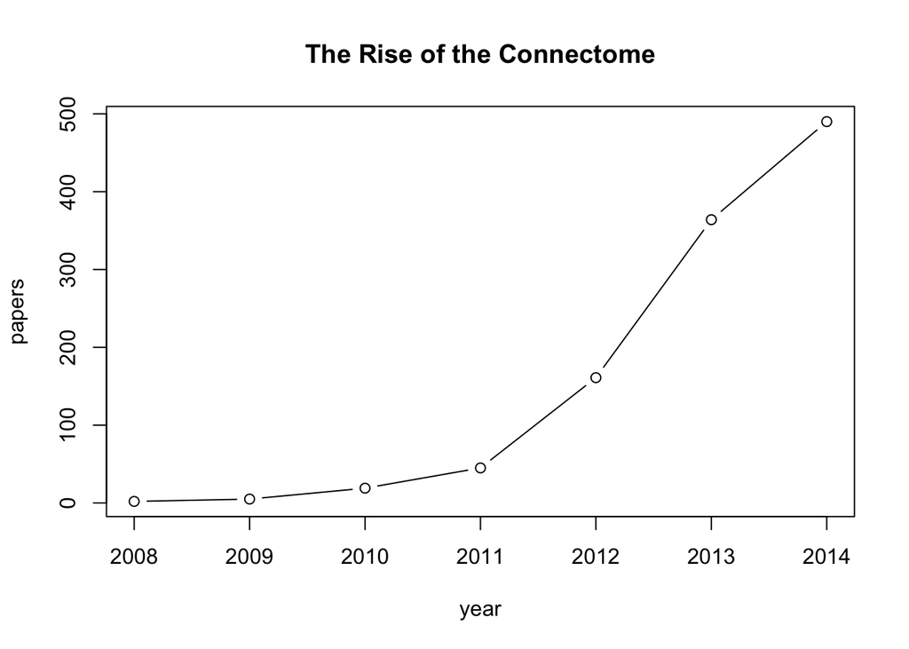

```r
library(rentrez)
search_year <- function(year, term){
    query <- paste(term, "AND (", year, "[PDAT])")
    entrez_search(db="pubmed", term=query, retmax=0)$count
}

year <- 2008:2014
papers <- sapply(year, search_year, term="Connectome", USE.NAMES=FALSE)

plot(year, papers, type='b', main="The Rise of the Connectome")
```

- Next example taken from Ted Hart’s workshop on ROpenscience at SIO14

## Search and plot trendy topics in genetics example

- We can also search pubmed abstracts with the [`rentrez`](https://github.com/ropensci/rentrez) package
- you can also use entrez to search pubmed and the EUtils API allows you to limit searches by the year in which the paper was published.
- For example we can find the trendiest -omics going around (this has quite a lot of repeated searching, so you want to run your own version be sure to do it in off peak times).
- Let’s start by making a function that finds the number of records matching a given search term for each of several years (using the mindate and maxdate terms from the Eutils API):

### Load packages in RStudio

```r
library(rentrez)
library(reshape2)
library(ggplot2)
```

### Create a function

```r
papers_by_year <- function(years, search_term){
  return(sapply(years, function(y) entrez_search(db="pubmed", term = search_term, mindate=y, maxdate=y, retmax=0)$count))
}
```

- With that we can fetch the data for each term and, by searching with no term, find the total number of papers published in each year:

```r
years <- 1990:2015
total_papers <- papers_by_year(years, "")
omics <- c("genomic", "epigenomic", "metagenomic", "proteomic", "transcriptomic", "pharmacogenomic", "connectomic" )
trend_data <- sapply(omics, function(t) papers_by_year(years, t))
trend_props <- trend_data/total_papers
```

- That’s the data, ready for plot:

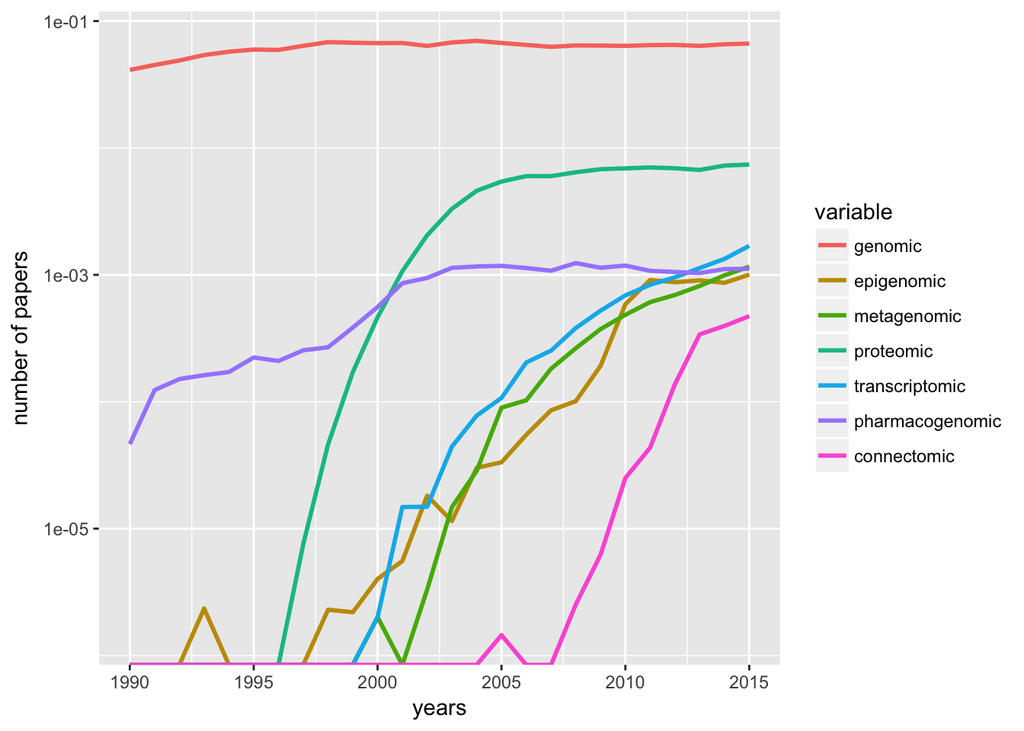

```r
trend_df <- melt(data.frame(years, trend_props), id.vars="years")
p <- ggplot(trend_df, aes(years, value, colour=variable))
p + geom_line(size=1) + scale_y_log10("number of papers")
```

### Full code

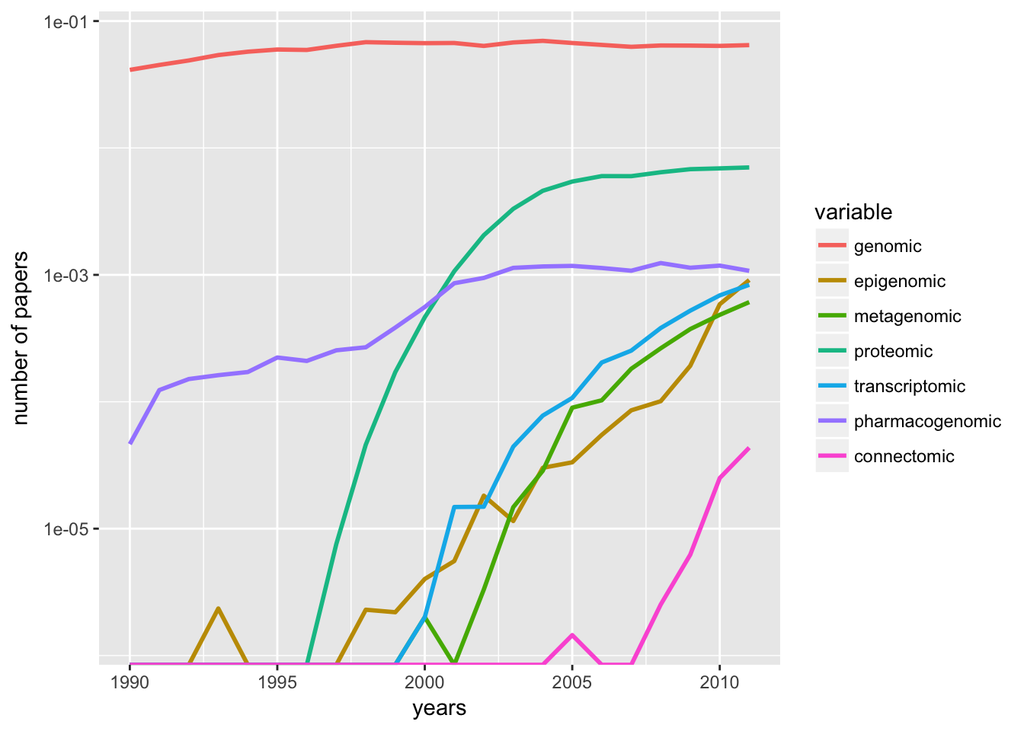

```r
papers_by_year <- function(years, search_term){
            return(sapply(years, function(y) entrez_search(db="pubmed",term=search_term, mindate=y, maxdate=y, retmax=0)$count))
        }

years <- 1990:2011
total_papers <- papers_by_year(years, "")
omics <- c("genomic", "epigenomic", "metagenomic", "proteomic", "transcriptomic", "pharmacogenomic", "connectomic" )
trend_data <- sapply(omics, function(t) papers_by_year(years, t))
trend_props <- data.frame(trend_data/total_papers)
trend_props$years <- years

trend_df <- melt(as.data.frame(trend_props), id.vars="years")
p <- ggplot(trend_df, aes(years, value, colour=variable))
p + geom_line(size=1) + scale_y_log10("number of papers")
```